# Reducción de datos con conjunto de datos Titanic

Reducción de datos con el dataset [titanic](https://www.kaggle.com/c/titanic/).

**En este cuaderno ampliaremos el código desarrollado en *titanic.Rmd* para seleccionar automáticamente las variables que se utilizarán para construir el modelo de predicción.**

Para ello, nos basaremos en la premisa de que diversos algoritmos de [`caret`](http://topepo.github.io/caret/) [ya incluyen procedimientos para selección de variables](https://topepo.github.io/caret/feature-selection-overview.html#builtin).

Para un ejemplo detallado basado en uso de correlaciones entre variables, ver el análisis con el problema de prácticas Lending Club.

# Lectura y preprocesamiento de datos

Comenzamos leyendo el fichero de datos:

```r
library(tidyverse)
data_raw <- read_csv('train.csv')
head(data_raw)
```

| PassengerId | Survived | Pclass | Name | Sex | Age | SibSp | Parch | Ticket | Fare | Cabin | Embarked |
| --- | --- | --- | --- | --- | --- | --- | --- | --- | --- | --- | --- |
| 1 | 0 | 3 | Braund, Mr. Owen Harris | male | 22 | 1 | 0 | A/5 21171 | 7.2500 | NA | S |
| 2 | 1 | 1 | Cumings, Mrs. John Bradley (Florence Briggs Thayer) | female | 38 | 1 | 0 | PC 17599 | 71.2833 | C85 | C |
| 3 | 1 | 3 | Heikkinen, Miss. Laina | female | 26 | 0 | 0 | STON/O2. 3101282 | 7.9250 | NA | S |
| 4 | 1 | 1 | Futrelle, Mrs. Jacques Heath (Lily May Peel) | female | 35 | 1 | 0 | 113803 | 53.1000 | C123 | S |
| 5 | 0 | 3 | Allen, Mr. William Henry | male | 35 | 0 | 0 | 373450 | 8.0500 | NA | S |
| 6 | 0 | 3 | Moran, Mr. James | male | NA | 0 | 0 | 330877 | 8.4583 | NA | Q |

A continuación, preprocesamos los datos para quedarnos con las variables que vamos a utilizar y recodificar la variable objetivo `Survived`. Las filas con valores NA se excluyen del proceso:

```r
data <-
  data_raw %>%
  mutate(Survived = as.factor(ifelse(Survived == 1, 'Yes', 'No'))) %>%
  mutate(Pclass = as.factor(Pclass)) %>%
  select(Survived, Pclass, Sex, Age, SibSp, Parch, Fare, Embarked) %>%
  na.exclude()
```

# Creación de modelo predictivo

Una vez están listos los datos, podemos crear un modelo predictivo que evalúa la importancia de las variables, como por ejemplo [`rpart`](https://cran.r-project.org/web/packages/rpart/).

### Entrenamiento

Creamos el modelo predictivo:

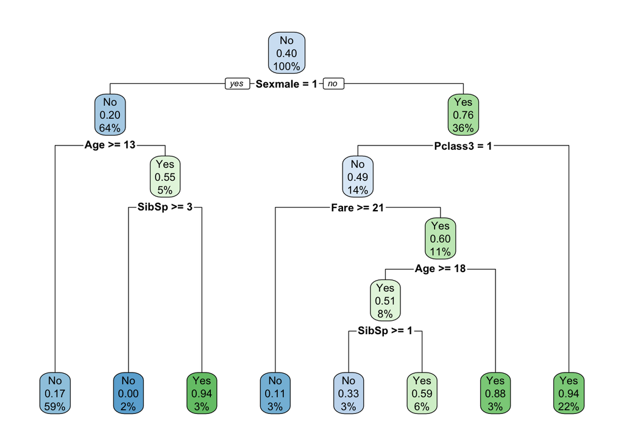

```r
# Parámetros
rpartCtrl <- trainControl(verboseIter = F, classProbs = TRUE, summaryFunction = twoClassSummary)
rpartParametersGrid <- expand.grid(.cp = c(0.01, 0.05))

# Conjuntos de entrenamiento y validación
trainIndex <- createDataPartition(data$Survived, p = .8, list = FALSE, times = 1)
train <- data[trainIndex, ]

# Entrenamiento del modelo
rpartModel <- train(Survived ~ .,
                    data = train,
                    method = "rpart",
                    metric = "ROC",
                    trControl = rpartCtrl,
                    tuneGrid = rpartParametersGrid)

# Visualización del modelo
rpart.plot(rpartModel$finalModel)
```

### Validación

Obtenemos resultados con el conjunto de validación:

```r
# Predicciones con clases
val        <- data[-trainIndex, ]
prediction <- predict(rpartModel, val, type = "raw")

# Predicciones con probabilidades
predictionValidationProb <- predict(rpartModel, val, type = "prob")
```

Y calculamos las métricas de calidad del clasificador (matriz de confusión y curva ROC):

```r
cm_train <- confusionMatrix(prediction, val[["Survived"]])
cm_train
```

```
## Confusion Matrix and Statistics
##
##           Reference
## Prediction No Yes
##        No  75  17
##        Yes  9  40
##
##                Accuracy : 0.8156
##                  95% CI : (0.7416, 0.8759)
##     No Information Rate : 0.5957
##     P-Value [Acc > NIR] : 1.91e-08
##
##                   Kappa : 0.6083
##
##  Mcnemar's Test P-Value : 0.1698
##
##             Sensitivity : 0.8929
##             Specificity : 0.7018
##          Pos Pred Value : 0.8152
##          Neg Pred Value : 0.8163
##              Prevalence : 0.5957
##          Detection Rate : 0.5319
##    Detection Prevalence : 0.6525
##       Balanced Accuracy : 0.7973
##
##        'Positive' Class : No
##
```

```r
auc <- roc(val$Survived, predictionValidationProb[["Yes"]], levels = unique(val[["Survived"]]))
```

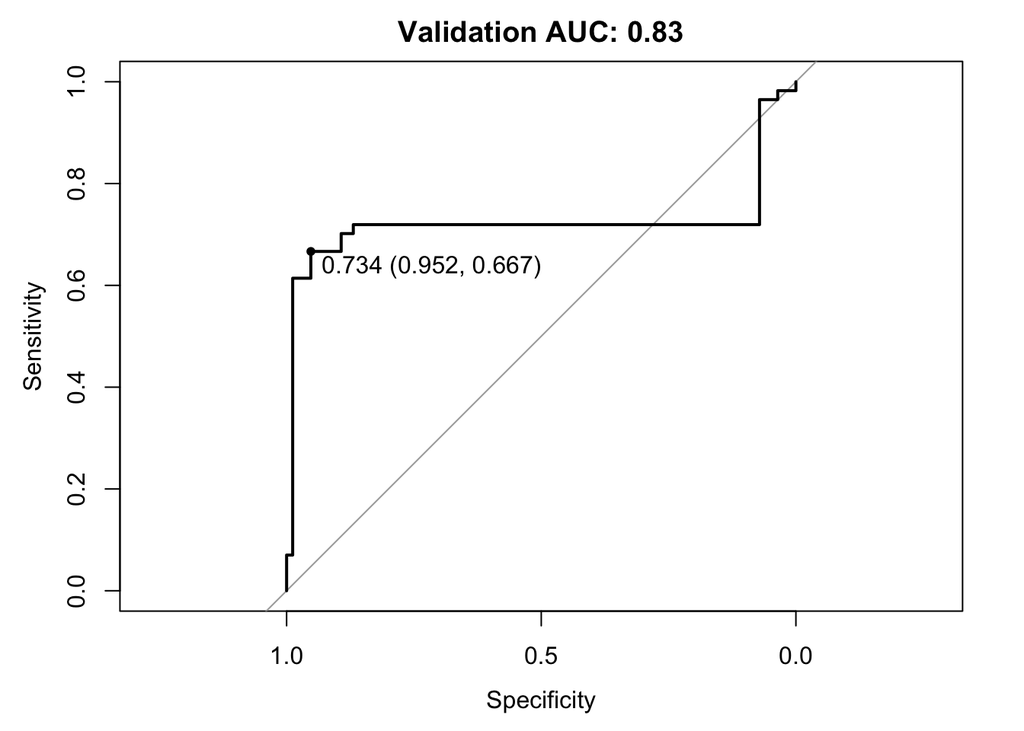

```r
roc_validation <- plot.roc(auc,
                           ylim=c(0,1),
                           type = "S" ,
                           print.thres = TRUE,
                           main=paste('Validation AUC:', round(auc$auc[[1]], 2)))
```

### Otros modelos de predicción

Otro modelo de predicción que calcula importancia de variables es [`rf`](https://cran.r-project.org/web/packages/randomForest/) (Random Forest):

```r
rfModel <- train(Survived ~ ., data = train, method = "rf", metric = "ROC", trControl = rpartCtrl)
predictionValidationProb <- predict(rfModel, val, type = "prob")
auc <- roc(val$Survived, predictionValidationProb[["Yes"]], levels = unique(val[["Survived"]]))
```

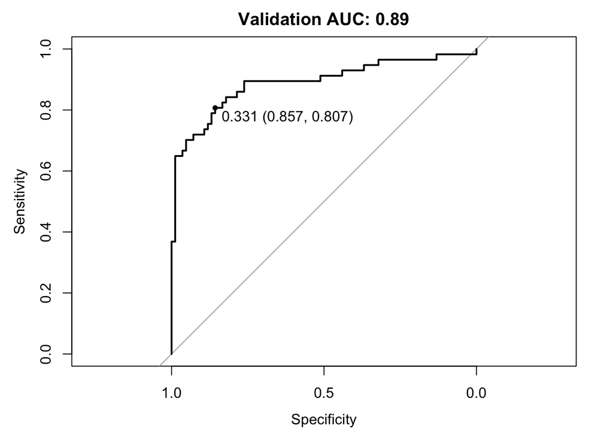

```r
roc_validation <- plot.roc(auc,
                           ylim=c(0,1),
                           type = "S" ,
                           print.thres = TRUE,
                           main=paste('Validation AUC:', round(auc$auc[[1]], 2)))
```

# Importancia de las variables con modelo de predicción

Una vez que los modelos han sido entrenados, podemos estudiar la importancia que cada otorga a las variabales utilizando [`varImp`](https://topepo.github.io/caret/variable-importance.html) en [`caret`](http://topepo.github.io/caret/):

```r
varImp(rpartModel)
```

```
## rpart variable importance
##
##           Overall
## Sexmale   100.000
## Pclass3    65.275
## Fare       60.735
## SibSp      25.999
## Age        19.530
## Parch      18.268
## EmbarkedS  17.827
## Pclass2     4.376
## EmbarkedQ   0.000
```

```r
varImp(rfModel)
```

```
## rf variable importance
##
##           Overall
## Sexmale   100.000
## Fare       52.947
## Age        47.375
## Pclass3    23.778
## SibSp      13.140
## Parch      11.497
## EmbarkedS   7.349
## Pclass2     4.239
## EmbarkedQ   0.000
```

El ranking obtenido puede servir para seleccionar las variables que se utilizarán para abordar el problema; por ejemplo aquellas con valor `Overall` por encima de 25. Esta selección se puede automatizar parcialmente, ya que tanto `rpart` como `rf` usan variables ‘dummy’ (por ejemplo, `Sexmale`) que no están en el dataset original.

```r
important_vars <- varImp(rfModel)$importance %>%
  rownames_to_column() %>%
  filter(Overall > 25) %>%
  select(rowname)
```

El orden de importancia se corresponden aproximadamente con el valor absoluto de correlación entre cada variable y la variable objetivo:

```r
# correlation_table(data, target='Survived')
data_num <-
  data %>%
  mutate_if(is.character, as.factor) %>%
  mutate_if(is.factor, as.numeric)
cor(data_num)
```

```
##             Survived      Pclass         Sex         Age       SibSp
## Survived  1.00000000 -0.35646159 -0.53676162 -0.08244587 -0.01552302
## Pclass   -0.35646159  1.00000000  0.15082621 -0.36590186  0.06518706
## Sex      -0.53676162  0.15082621  1.00000000  0.09903723 -0.10629611
## Age      -0.08244587 -0.36590186  0.09903723  1.00000000 -0.30735094
## SibSp    -0.01552302  0.06518706 -0.10629611 -0.30735094  1.00000000
## Parch     0.09526529  0.02366612 -0.24954273 -0.18789649  0.38333753
## Fare      0.26609960 -0.55289322 -0.18245683  0.09314252  0.13986049
## Embarked -0.18197934  0.24414499  0.10963900 -0.03256492  0.03306447
##                Parch        Fare    Embarked
## Survived  0.09526529  0.26609960 -0.18197934
## Pclass    0.02366612 -0.55289322  0.24414499
## Sex      -0.24954273 -0.18245683  0.10963900
## Age      -0.18789649  0.09314252 -0.03256492
## SibSp     0.38333753  0.13986049  0.03306447
## Parch     1.00000000  0.20662367  0.01180289
## Fare      0.20662367  1.00000000 -0.28351044
## Embarked  0.01180289 -0.28351044  1.00000000
```

```r
# correlation_table(data_num, target='Survived')
```

Visualmente, podemos verlo como tabla de correlación o como mapa de calor:

```r
rcorr(as.matrix(data_num))
```

```
##          Survived Pclass   Sex   Age SibSp Parch  Fare Embarked
## Survived     1.00  -0.36 -0.54 -0.08 -0.02  0.10  0.27    -0.18
## Pclass      -0.36   1.00  0.15 -0.37  0.07  0.02 -0.55     0.24
## Sex         -0.54   0.15  1.00  0.10 -0.11 -0.25 -0.18     0.11
## Age         -0.08  -0.37  0.10  1.00 -0.31 -0.19  0.09    -0.03
## SibSp       -0.02   0.07 -0.11 -0.31  1.00  0.38  0.14     0.03
## Parch        0.10   0.02 -0.25 -0.19  0.38  1.00  0.21     0.01
## Fare         0.27  -0.55 -0.18  0.09  0.14  0.21  1.00    -0.28
## Embarked    -0.18   0.24  0.11 -0.03  0.03  0.01 -0.28     1.00
##
## n= 712
##
##
## P
##          Survived Pclass Sex    Age    SibSp  Parch  Fare   Embarked
## Survived          0.0000 0.0000 0.0278 0.6792 0.0110 0.0000 0.0000
## Pclass   0.0000          0.0000 0.0000 0.0822 0.5284 0.0000 0.0000
## Sex      0.0000   0.0000        0.0082 0.0045 0.0000 0.0000 0.0034
## Age      0.0278   0.0000 0.0082        0.0000 0.0000 0.0129 0.3856
## SibSp    0.6792   0.0822 0.0045 0.0000        0.0000 0.0002 0.3783
## Parch    0.0110   0.5284 0.0000 0.0000 0.0000        0.0000 0.7532
## Fare     0.0000   0.0000 0.0000 0.0129 0.0002 0.0000        0.0000
## Embarked 0.0000   0.0000 0.0034 0.3856 0.3783 0.7532 0.0000
```

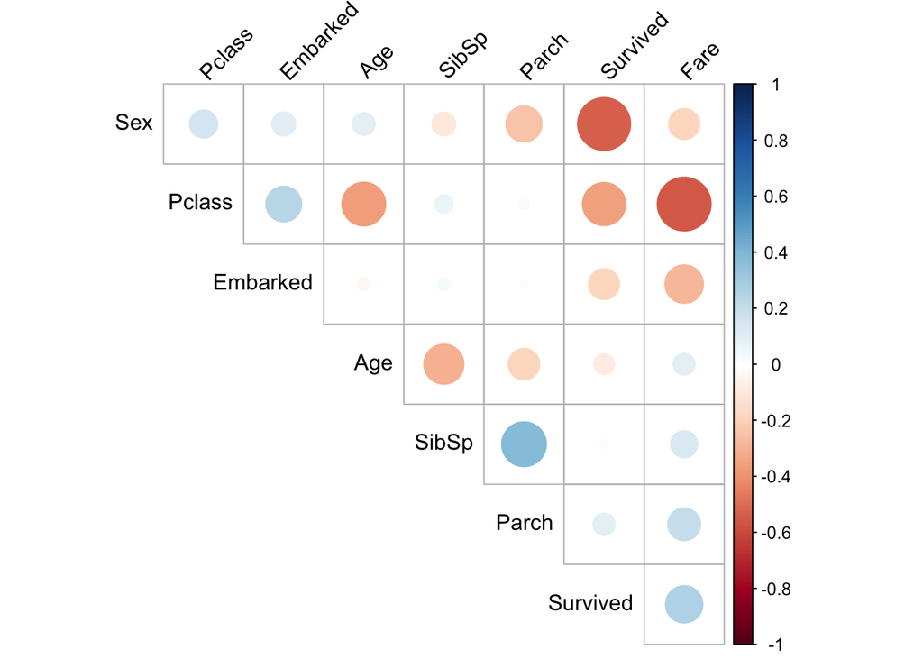

```r
corrplot(cor(data_num), type = "upper", diag = F, order = "hclust", tl.col = "black", tl.srt = 45)
```

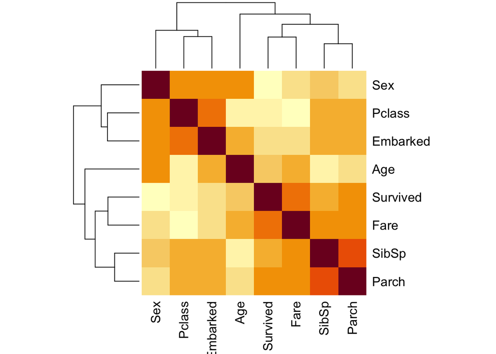

```r
heatmap(x = cor(data_num), symm = TRUE)
```

# Importancia de las variables sin modelo de predicción

También se puede conocer la importancia de las variables sin crear explícitamente un modelo de predicción, sino simplemente calculando los mismos parámetros que se utilizan para aprender los modelos. Por ejemplo, los modelos de árboles utilizan la ganancia de información o la entropía para decidir sobre qué variables ramificar. Con var_rank_info podemos estimar varios estos valores directamente:

- en: entropy measured in bits
- mi: mutual information
- ig: information gain
- gr: gain ratio

```r
var_rank_info(data, "Survived")
```

|  | var | en | mi | ig | gr |
| --- | --- | --- | --- | --- | --- |
| en1 | Sex | 1.705 | 0.214 | 0.21410831 | 0.22638678 |
| en5 | Fare | 7.500 | 0.457 | 0.45650850 | 0.06537621 |
| en | Pclass | 2.381 | 0.094 | 0.09400998 | 0.06262926 |
| en6 | Embarked | 1.859 | 0.028 | 0.02785821 | 0.03050629 |
| en4 | Parch | 2.171 | 0.031 | 0.03068201 | 0.02498243 |
| en2 | Age | 6.680 | 0.127 | 0.12724736 | 0.02181265 |
| en3 | SibSp | 2.302 | 0.025 | 0.02486899 | 0.01836950 |

# Entrenamiento del modelo con selección de variables

Una vez determinadas las variables importantes, podemos entrenar modelos seleccionando solamente estas variables importantes:

```r
data_reduced <-
  data %>%
  select(Survived, Sex, Fare, Age, Pclass, SibSp)
head(data_reduced)
```

| Survived | Sex | Fare | Age | Pclass | SibSp |
| --- | --- | --- | --- | --- | --- |
| No | male | 7.2500 | 22 | 3 | 1 |
| Yes | female | 71.2833 | 38 | 1 | 1 |
| Yes | female | 7.9250 | 26 | 3 | 0 |
| Yes | female | 53.1000 | 35 | 1 | 1 |
| No | male | 8.0500 | 35 | 3 | 0 |
| No | male | 51.8625 | 54 | 1 | 0 |

```r
train <- data_reduced[trainIndex, ]
val   <- data_reduced[-trainIndex, ]

# rpart
rpartModel_2 <- train(Survived ~ ., data = train, method = "rpart", metric = "ROC", trControl = rpartCtrl, tuneGrid = rpartParametersGrid)
auc_rpart_2 <- roc(val$Survived, predictionValidationProb[["Yes"]], levels = unique(val[["Survived"]]))
auc_rpart_2
```

```
##
## Call:
## roc.default(response = val$Survived, predictor = predictionValidationProb[["Yes"]],     levels = unique(val[["Survived"]]))
##
## Data: predictionValidationProb[["Yes"]] in 84 controls (val$Survived 1) < 57 cases (val$Survived 2).
## Area under the curve: 0.8906
```

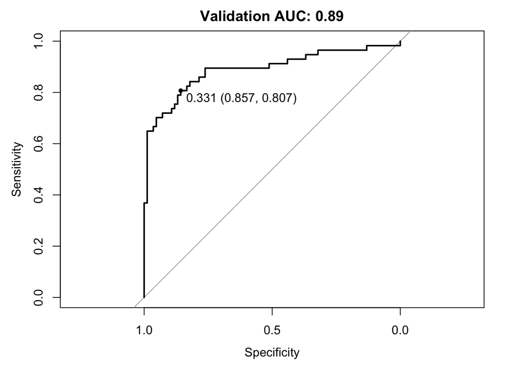

```r
roc_rpart_2 <- plot.roc(auc_rpart_2, ylim=c(0,1), type = "S" , print.thres = T, main=paste('Validation AUC:', round(auc_rpart_2$auc[[1]], 2)))
```

```r
# rf
rfModel_2 <- train(Survived ~ ., data = train, method = "rf", metric = "ROC", trControl = rpartCtrl)
predictionValidationProb <- predict(rfModel_2, val, type = "prob")
auc_rf_2 <- roc(val$Survived, predictionValidationProb[["Yes"]], levels = unique(val[["Survived"]]))
auc_rf_2
```

```
##
## Call:
## roc.default(response = val$Survived, predictor = predictionValidationProb[["Yes"]],     levels = unique(val[["Survived"]]))
##
## Data: predictionValidationProb[["Yes"]] in 84 controls (val$Survived 1) < 57 cases (val$Survived 2).
## Area under the curve: 0.9084
```

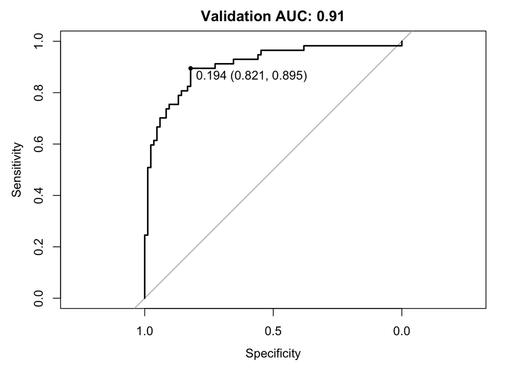

```r
roc_rf_2 <- plot.roc(auc_rf_2, ylim=c(0,1), type = "S" , print.thres = T, main=paste('Validation AUC:', round(auc_rf_2$auc[[1]], 2)))
```

```r
# comparacion
roc.test(roc_rf_2, roc_rpart_2)
```

```
##
##  DeLong's test for two correlated ROC curves
##
## data:  roc_rf_2 and roc_rpart_2
## Z = 1.6607, p-value = 0.09677
## alternative hypothesis: true difference in AUC is not equal to 0
## 95 percent confidence interval:
##  -0.003217525  0.038931811
## sample estimates:
## AUC of roc1 AUC of roc2
##   0.9084169   0.8905597
```

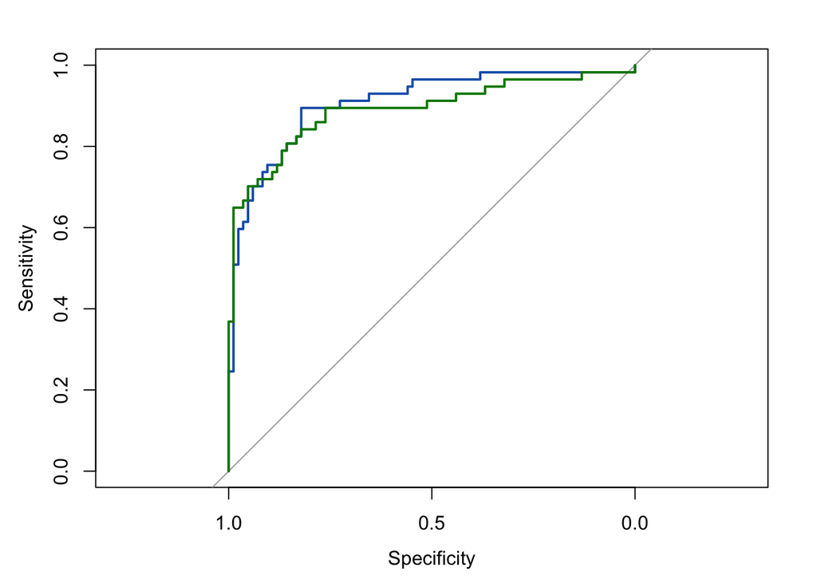

```r
plot.roc(auc_rf_2, type = "S", col="#1c61b6")
lines.roc(roc_rpart_2, type = "S", col="#008600")
```

# Bola extra: PCA

Para hacer la selección de variables podemos utilizar también otras técnicas geométricas, como PCA o tSNE.

PCA (Principal Component Analysis) es una técnica clásica de reducción de dimensionalidad. Está basada en la proyección geométrica de los datos desde el espacio vectorial original a un espacio de menor dimensión. Esta proyección minimiza la pérdida debida a esta compresión y se construye a partir de los autovalores de la matriz de covarianza.

## PCA con `prcomp()`

Existen varias implementaciones de PCA para R. La más básica es `prcomp()`, que no requiere paquetes adicionales. PCA trabaja con valores numéricos, por lo que es necesario en primer lugar recodificar las variables categóricas.

```r
train_num <-
  data[trainIndex, ]  %>%
  mutate_if(is.character, as.factor) %>%
  mutate_if(is.factor, as.numeric)

val_num <-
  data[-trainIndex, ]  %>%
  mutate_if(is.character, as.factor) %>%
  mutate_if(is.factor, as.numeric)
```

Ahora podemos aplicar `prcomp()`:

```r
pca <- prcomp(train_num[,-1], scale=TRUE)
summary(pca)
```

```
## Importance of components:
##                           PC1    PC2    PC3    PC4     PC5     PC6     PC7
## Standard deviation     1.3892 1.3316 0.9568 0.9209 0.78242 0.74965 0.59929
## Proportion of Variance 0.2757 0.2533 0.1308 0.1211 0.08745 0.08028 0.05131
## Cumulative Proportion  0.2757 0.5290 0.6598 0.7810 0.86841 0.94869 1.00000
```

Para visualizar gráficamente la proyección podemos usar `ggbiplot` del paquete [`ggbiplot`](https://github.com/vqv/ggbiplot). Puede requerir instalar previamente [`devtools`](https://www.r-project.org/nosvn/pandoc/devtools.html) y [`ggbiplot`](https://github.com/vqv/ggbiplot) con `install_github("vqv/ggbiplot")`.

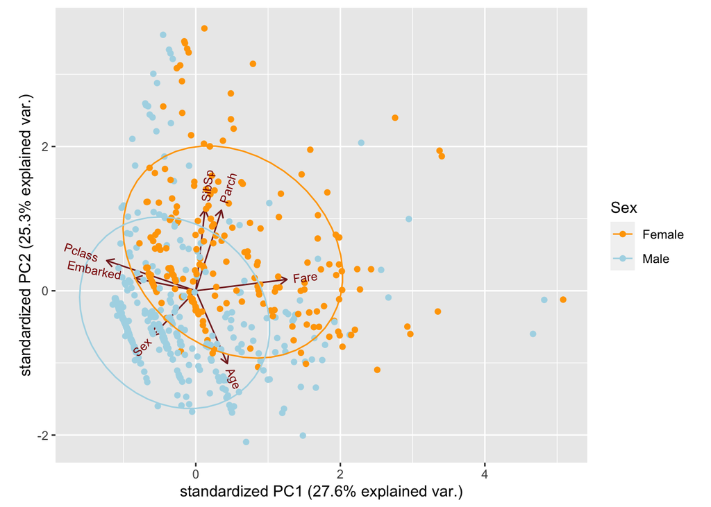

```r
library(ggbiplot)
ggbiplot(pca, groups = as.factor(train_num$Sex), ellipse = TRUE) +
  scale_colour_manual(name="Sex", labels= c("Female", "Male"), values= c("orange", "lightblue"))
```

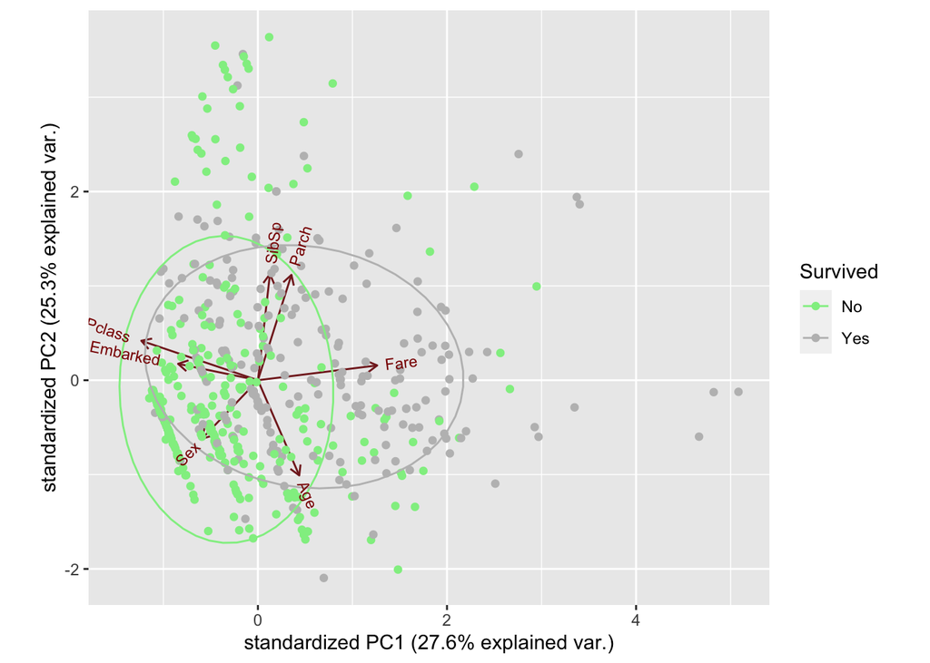

```r
ggbiplot(pca, groups = as.factor(train_num$Survived), ellipse = TRUE) +
  scale_colour_manual(name="Survived", labels= c("No", "Yes"), values= c("lightgreen", "grey"))
```

Con las componentes principales calculadas, podemos entrenar un modelo con la proyección obtenida con un subconjunto de componentes principales; por ejemplo, `PC1` a `PC4`. La proyección se realiza con la función `predict()` sobre un objeto `pca` (no confundir con el `predict()` de `caret`).

```r
train_samples_proj <- predict(pca, train_num)
train_proj <- as_tibble(train_samples_proj[,1:4]) %>%
  mutate(Survived = train$Survived)

# rpart con PCA
rpartModel_3 <- train(Survived ~ .,
                      data = train_proj,
                      method = "rpart",
                      metric = "ROC",
                      trControl = rpartCtrl,
                      tuneGrid = rpartParametersGrid)

rpartModel_3
```

```
## CART
##
## 571 samples
##   4 predictor
##   2 classes: 'No', 'Yes'
##
## No pre-processing
## Resampling: Bootstrapped (25 reps)
## Summary of sample sizes: 571, 571, 571, 571, 571, 571, ...
## Resampling results across tuning parameters:
##
##   cp    ROC        Sens       Spec
##   0.01  0.7685810  0.8086910  0.6450910
##   0.05  0.7181947  0.8050754  0.6034406
##
## ROC was used to select the optimal model using the largest value.
## The final value used for the model was cp = 0.01.
```

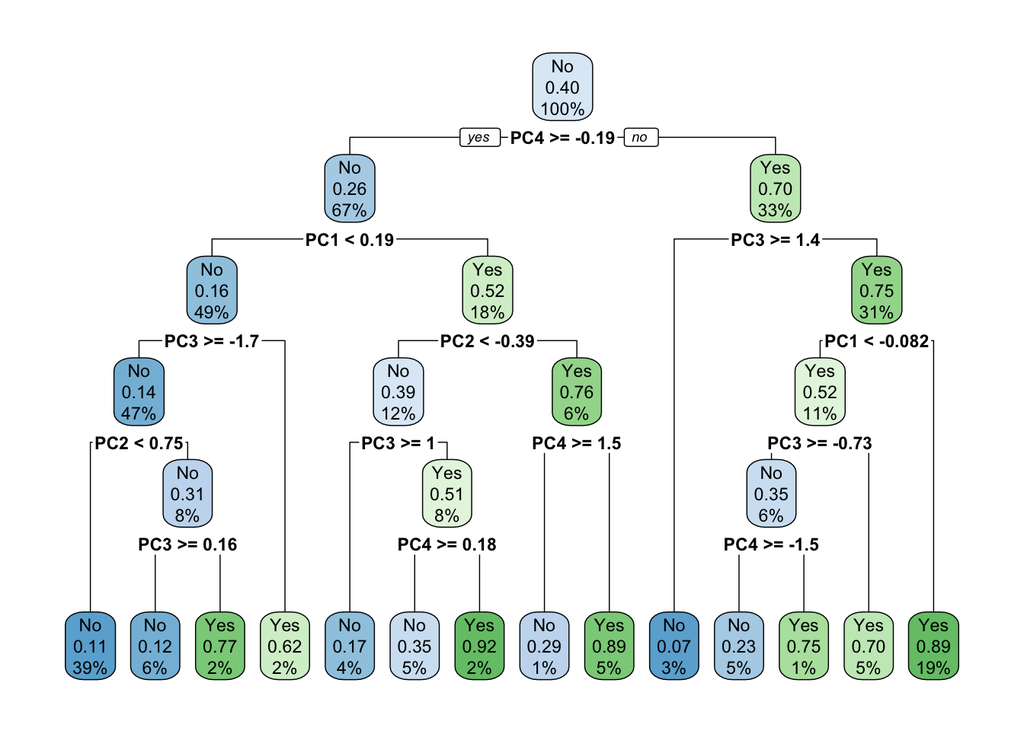

```r
rpart.plot(rpartModel_3$finalModel)
```

Para la validación, hay que proyectar también los datos:

```r
val_samples_proj <- predict(pca, val_num)
val_proj <- as_tibble(val_samples_proj[,1:4]) %>%
  mutate(Survived = val$Survived)

predictionValidationProb <- predict(rpartModel_3, val_proj, type = "prob")

auc_rpart_3 <- roc(val_proj$Survived, predictionValidationProb[["Yes"]], levels = unique(val_proj[["Survived"]]))
auc_rpart_3
```

```
##
## Call:
## roc.default(response = val_proj$Survived, predictor = predictionValidationProb[["Yes"]],     levels = unique(val_proj[["Survived"]]))
##
## Data: predictionValidationProb[["Yes"]] in 84 controls (val_proj$Survived 1) < 57 cases (val_proj$Survived 2).
## Area under the curve: 0.8195
```

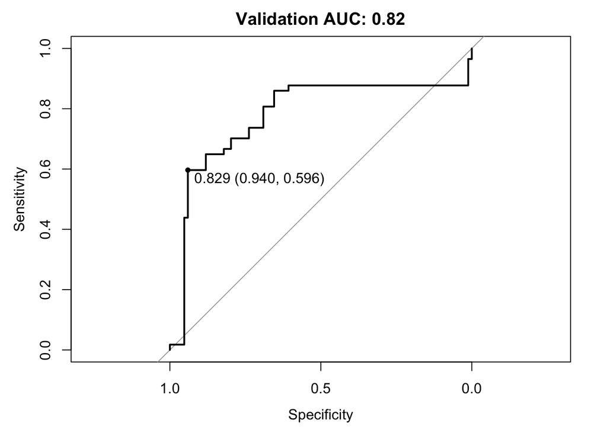

```r
roc_rpart_3 <- plot.roc(auc_rpart_3, ylim=c(0,1), type = "S" , print.thres = T, main=paste('Validation AUC:', round(auc_rpart_3$auc[[1]], 2)))
```

## PCA con `caret`

Es posible integrar PCA dentro del flujo de trabajo de `caret` utilizando la función [`preProcess`](https://topepo.github.io/caret/pre-processing.html), que admite diferentes métodos de preprocesamiento.

```r
train_preprocess <- preProcess(data[trainIndex, -1], method = c("pca"))
train_preprocess
```

```
## Created from 571 samples and 7 variables
##
## Pre-processing:
##   - centered (4)
##   - ignored (3)
##   - principal component signal extraction (4)
##   - scaled (4)
##
## PCA needed 4 components to capture 95 percent of the variance
```

A partir de los datos preprocesados, el proceso continuaría como en el ejemplo previo. Primero, los datos de entrenamiento se proyectan con `predict` y el objeto `preprocess`. Después, sobre los datos proyectados, se entrena el clasificador.

```r
train_samples_proj <- predict(train_preprocess, data[trainIndex, -1])
train_proj <- as_tibble(train_samples_proj[,4:7]) %>%    # [1:3] son las variables categóricas
  mutate(Survived = train$Survived)

# rpart con PCA
rpartModel_4 <- train(Survived ~ .,
                      data = train_proj,
                      method = "rpart",
                      metric = "ROC",
                      trControl = rpartCtrl,
                      tuneGrid = rpartParametersGrid)

rpartModel_4
```

```
## CART
##
## 571 samples
##   4 predictor
##   2 classes: 'No', 'Yes'
##
## No pre-processing
## Resampling: Bootstrapped (25 reps)
## Summary of sample sizes: 571, 571, 571, 571, 571, 571, ...
## Resampling results across tuning parameters:
##
##   cp    ROC        Sens       Spec
##   0.01  0.6683839  0.7774766  0.5215079
##   0.05  0.6217504  0.8790891  0.3613539
##
## ROC was used to select the optimal model using the largest value.
## The final value used for the model was cp = 0.01.
```

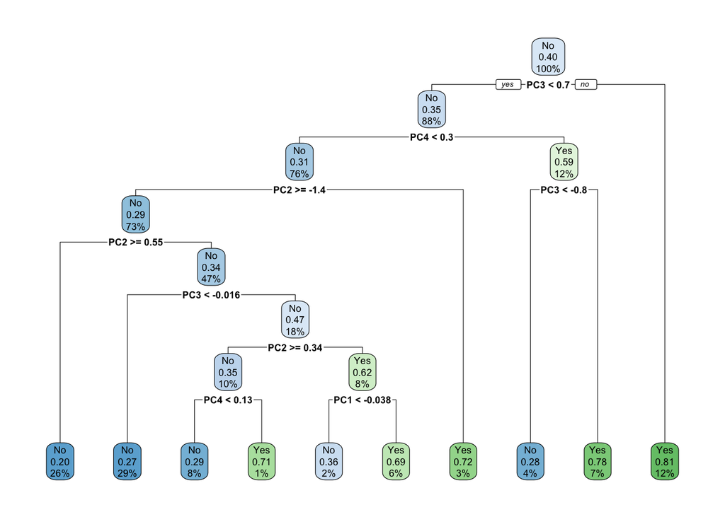

```r
rpart.plot(rpartModel_4$finalModel)
```

Y, finalmente, se vuelve a hacer validación, con los datos proyectados con el mismo `train_preprocess` anterior.

```r
val_samples_proj <- predict(train_preprocess, data[-trainIndex, -1])
val_proj <- as_tibble(val_samples_proj[,4:7]) %>%
  mutate(Survived = val$Survived)

predictionValidationProb <- predict(rpartModel_4, val_proj, type = "prob")

auc_rpart_4 <- roc(val_proj$Survived, predictionValidationProb[["Yes"]], levels = unique(val_proj[["Survived"]]))
auc_rpart_4
```

```
##
## Call:
## roc.default(response = val_proj$Survived, predictor = predictionValidationProb[["Yes"]],     levels = unique(val_proj[["Survived"]]))
##
## Data: predictionValidationProb[["Yes"]] in 84 controls (val_proj$Survived 1) < 57 cases (val_proj$Survived 2).
## Area under the curve: 0.6864
```

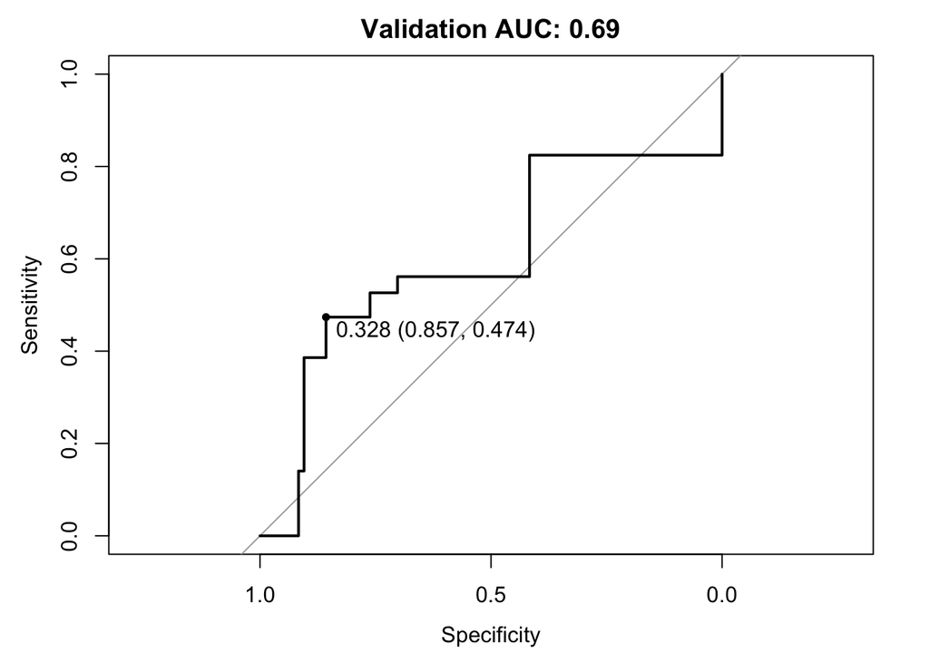

```r
roc_rpart_4 <- plot.roc(auc_rpart_4, ylim=c(0,1), type = "S" , print.thres = T, main=paste('Validation AUC:', round(auc_rpart_4$auc[[1]], 2)))
```